# Tema I.1: Gráficos de Distribuciones

Autor/a

LÿRA  
L.RodriguezAragon@uclm.es

Fecha de publicación

25 de enero de 2025

**Estadística (Grados en Ingeniería 2025 / 2026)**

Licesio J. Rodríguez Aragón  
Escuela Ing. Industrial y Aeroespacial de Toledo  
Departamento de Matemáticas  
Universidad de Castilla-La Mancha

# Bloque I: Estadística Descriptiva

## Tema I.1: Gráficos de Distribuciones [(p. 4)](https://elibro.net/es/ereader/bibliotecauclm/60046?page=46)

### Individuos y Variables

Los **individuos** son los objetos descritos por un conjunto de datos. Los individuos pueden ser personas, pero también pueden ser animales o cosas.

Una **variable** es cualquier característica de un individuo. Una variable puede tomar distintos valores para distintos individuos.

### Variables Categóricas y Variables Numéricas

Una **variable categórica** indica a qué grupo o categoría pertenece un individuo.

Una **variable cuantitativa** toma valores numéricos, para los que tiene sentido hacer operaciones aritméticas como sumas y medias.

La **distribución de una variable** nos dice qué valores toma y con qué frecuencia.

> Autoevaluación I.1.1: Prueba a hacer el Ejercicio 1.2 [(p. 6)](https://elibro.net/es/ereader/bibliotecauclm/60046?page=48)

### Caso

Cada fila describe a un individuo. A menudo, a cada fila de datos se le llama **un caso**. Cada columna contiene los valores de una variable para todos los individuos.

### Hoja de Cálculo

Estos datos se presentan en una **hoja de cálculo** (en R **dataframe**) que contiene filas y columnas preparadas para su utilización. Las hojas de cálculo se utilizan frecuentemente para entrar y transmitir datos.

Ejemplo de [Reactores Nucleares Españoles](https://docs.google.com/spreadsheets/d/14JQZUSntPX2ph0tY8CiriKXuvFi25sln5sgLsVALAgI/edit?usp=sharing).

```r
getwd()
```

```
[1] "C:/Users/lrodr/Documents/OneDrive - Universidad de Castilla-La Mancha/Licesio/Docencia/E_EIIA/2025_2026/Teoria"
```

```r
setwd("C://Users//lrodr//Documents//OneDrive - Universidad de Castilla-La Mancha//R")
getwd()
```

```
[1] "C:/Users/lrodr/Documents/OneDrive - Universidad de Castilla-La Mancha/R"
```

```r
ReactoresNucleares<-read.table("ReactoresNucleares - Hoja 1.tsv",
                               header=TRUE, sep="\t")
ReactoresNucleares<-read.table("ReactoresNucleares - Hoja 1.csv",
                               header=TRUE, sep=",")

head(ReactoresNucleares)
```

```
  Provincia Tipo        Marca     Modelo Bruta.MW Neta.MW             Estado
1   Caceres  PWR Westinghouse WE 3-loops 1045.000    1004          Operativo
2   Caceres  PWR Westinghouse WE 3-loops 1044.000    1006          Operativo
3  Zaragoza                                    NA      NA Proyecto cancelado
4  Zaragoza                                    NA      NA Proyecto cancelado
5   Vizcaya  PTR      Argonne   Argonaut    0.010      NA       Desmantelado
6 Barcelona  PTR      Argonne   Argonaut    0.001      NA       Desmantelado
```

```r
mode(ReactoresNucleares)
```

```
[1] "list"
```

```r
length(ReactoresNucleares)
```

```
[1] 7
```

```r
dim(ReactoresNucleares)
```

```
[1] 41  7
```

#### Análisis Exploratorio de Datos

- Empieza examinando cada variable de forma separada. Luego, pasa al estudio de las relaciones entre variables.
- Empieza con los gráficos. Luego, añade resúmenes numéricos de aspectos concretos de los datos.

### Modalidades, Recuento y Porcentaje

Los valores de una **variable categórica** son etiquetas asignadas a las categorías de la misma.

La distribución de una variable categórica lista las categorías y da el recuento o el porcentaje de individuos de cada categoría.

```r
n<-dim(ReactoresNucleares)[1]
nvar<-dim(ReactoresNucleares)[2]
nrow(ReactoresNucleares)
```

```
[1] 41
```

```r
names(ReactoresNucleares)
```

```
[1] "Provincia" "Tipo"      "Marca"     "Modelo"    "Bruta.MW"  "Neta.MW"
[7] "Estado"
```

```r
ReactoresNucleares$Provincia
```

```
 [1] "Caceres"     "Caceres"     "Zaragoza"    "Zaragoza"    "Vizcaya"
 [6] "Barcelona"   "Tarragona"   "Tarragona"   "Huelva"      "Huelva"
[11] "Huesca"      "Murcia"      "Valencia"    "Madrid"      "Zaragoza"
[16] "Zaragoza"    "Burgos"      "Madrid"      "Tarragona"   "Tarragona"
[21] "Vizcaya"     "Vizcaya"     "Vizcaya"     "Vizcaya"     "Leon"
[26] "Guipuzcoa"   "Guipuzcoa"   "Lugo"        "Cantabria"   "Zamora"
[31] "Cadiz"       "Cadiz"       "Guadalajara" "Guadalajara" "Badajoz"
[36] "Badajoz"     "Tarragona"   "Tarragona"   "Tarragona"   "Navarra"
[41] "Guadalajara"
```

```r
table(ReactoresNucleares$Provincia)
```

```
    Badajoz   Barcelona      Burgos     Caceres       Cadiz   Cantabria
          2           1           1           2           2           1
Guadalajara   Guipuzcoa      Huelva      Huesca        Leon        Lugo
          3           2           2           1           1           1
     Madrid      Murcia     Navarra   Tarragona    Valencia     Vizcaya
          2           1           1           7           1           5
     Zamora    Zaragoza
          1           4
```

```r
cbind(table(ReactoresNucleares$Provincia))
```

```
            [,1]
Badajoz        2
Barcelona      1
Burgos         1
Caceres        2
Cadiz          2
Cantabria      1
Guadalajara    3
Guipuzcoa      2
Huelva         2
Huesca         1
Leon           1
Lugo           1
Madrid         2
Murcia         1
Navarra        1
Tarragona      7
Valencia       1
Vizcaya        5
Zamora         1
Zaragoza       4
```

```r
table(ReactoresNucleares$Provincia)/n*100
```

```
    Badajoz   Barcelona      Burgos     Caceres       Cadiz   Cantabria
   4.878049    2.439024    2.439024    4.878049    4.878049    2.439024
Guadalajara   Guipuzcoa      Huelva      Huesca        Leon        Lugo
   7.317073    4.878049    4.878049    2.439024    2.439024    2.439024
     Madrid      Murcia     Navarra   Tarragona    Valencia     Vizcaya
   4.878049    2.439024    2.439024   17.073171    2.439024   12.195122
     Zamora    Zaragoza
   2.439024    9.756098
```

```r
cbind(table(ReactoresNucleares$Provincia))/n*100
```

```
                 [,1]
Badajoz      4.878049
Barcelona    2.439024
Burgos       2.439024
Caceres      4.878049
Cadiz        4.878049
Cantabria    2.439024
Guadalajara  7.317073
Guipuzcoa    4.878049
Huelva       4.878049
Huesca       2.439024
Leon         2.439024
Lugo         2.439024
Madrid       4.878049
Murcia       2.439024
Navarra      2.439024
Tarragona   17.073171
Valencia     2.439024
Vizcaya     12.195122
Zamora       2.439024
Zaragoza     9.756098
```

> Autoevaluación I.1.2: Construye una tabla de recuento para la variable Región de los datos de la Tabla 1.6 [(p.31)](https://elibro.net/es/ereader/bibliotecauclm/60046?page=73)

> Prueba a modificar el código anterior para calcular tablas de recuento y de porcentaje de la variable `paises$UE_estado`, que describe el tipo de relación que tiene cada pais con la UE.

### Gráficos para variables categóricas: Diagrama de Barras y de Sectores

En el **diagrama de barras** se representan la frecuencia de cada categoría mediante una barra. La altura de cada barra es proporcional d la frecuencia. Las barras están separadas.

- Diagrama de barras de recuento.
- Diagrama de barras de porcentaje.

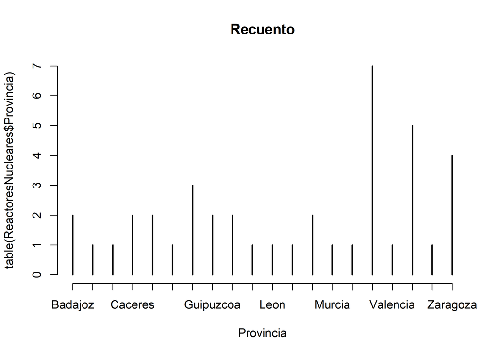

```r
plot(table(ReactoresNucleares$Provincia),main="Recuento", xlab="Provincia")
```

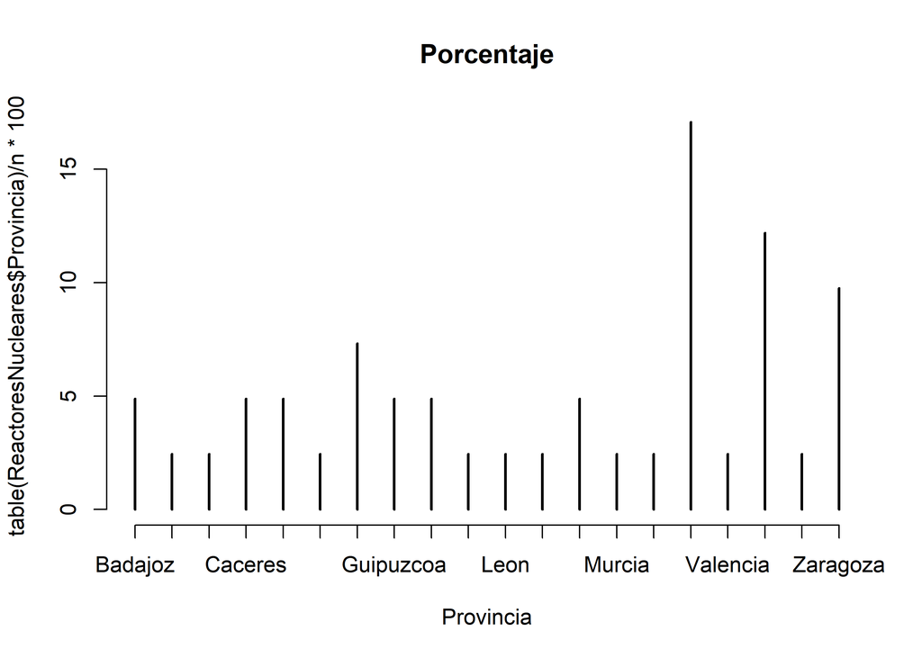

```r
plot(table(ReactoresNucleares$Provincia)/n*100, main="Porcentaje", xlab="Provincia")
```

En el **diagrama de sectores**, cada sector de circunferencia tiene un ángulo proporcional al recuento o porcentaje.

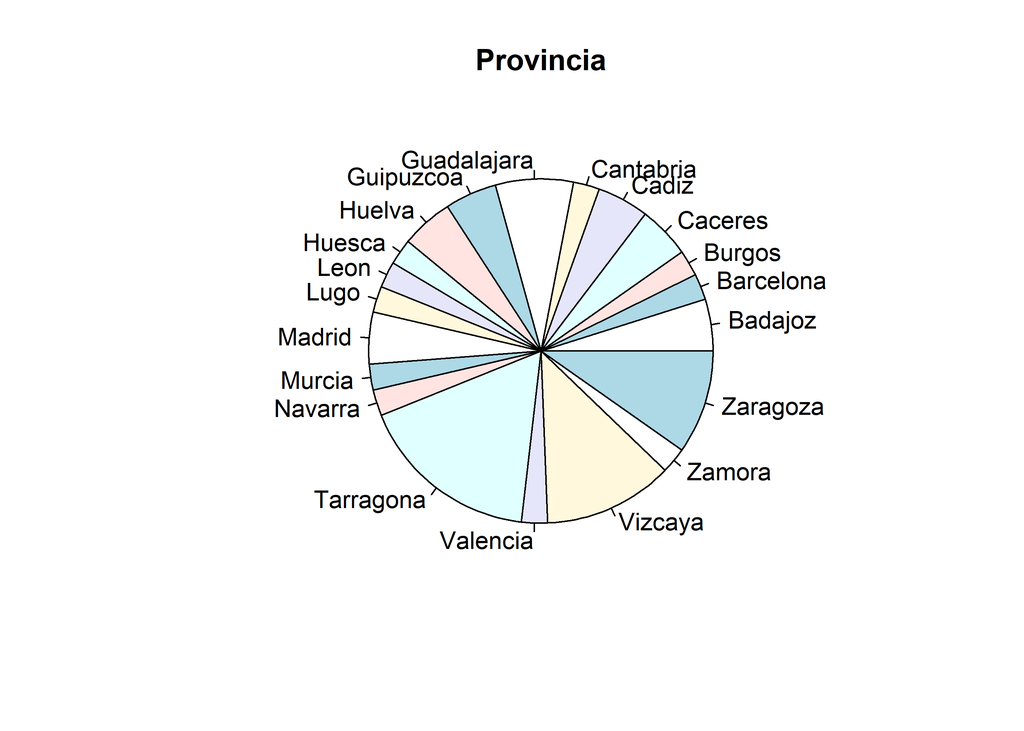

```r
pie(table(ReactoresNucleares$Provincia),main="Provincia")
```

> Autoevaluación I.1.3: Construye un resúmen Gráfico para la variable Región de los datos de la Tabla 1.6 [(p.31)](https://elibro.net/es/ereader/bibliotecauclm/60046?page=73)

> Prueba a modificar el código anterior para generar resúmenes gráficos de la variable `paises$UE_estado`.
- Construye gráficos absolutos y relativos, en qué se diferencian.
- Compara las funciones `plot` y `barplot`.

[Ejemplos de Datos Categóricos](https://docs.google.com/spreadsheets/d/1bFepkAvvZsgwxYKHoKCSSs8bkG5fizfxoj8axwGFG70/edit?usp=sharing)

### Gráficos para variables cuantitativas: Histograma

Cuando las variables cuantitativas toman muchos valores, el gráfico de la distribución es más claro si se agrupan los valores próximos. El gráfico más común para describir la distribución de una variable cuantitativa es un **histograma**.

- Paso 1: Divide el rango de valores de la variable cuantitativa en intervalos, exhaustivos y excluyentes, de tal manera que cada observación se situe en una sola clase. Es muy recomendable que los intervalos tengan la misma amplitud
- Paso 2: Haz un recuento del número de observaciones de cada clase.
- Paso 3: Dibuja **RECTÁNGULOS** cuya área sea proporcional al recuento de cada clase. Los rectángulos de cada clase estarán pegados a los rectángulos de las clases adyacentes.

Nuestra vista responde al área de las barras de un histograma. Debido a que todas las clases tienen la misma anchura, el área está determinada por la altura y todas las clases se representan de forma equitativa. No hay una sola elección correcta del número de clases de un histograma.

**PELIGRO**: Cuidado con histogramas en los que no todas las clases tienen la misma amplitud o anchura.

**Ejemplo:** Consumo de carretera de vehículos de 1996 [Consumo Carretera](https://docs.google.com/spreadsheets/d/1uSXMzS0Rr2xNIzQTmb1n4LRZkEo54qCQoEFpc52XUbY/edit?usp=sharing) (Tabla 1.2, [p. 12](https://elibro.net/es/ereader/bibliotecauclm/60046?page=54))

```r
setwd("C://Users//lrodr//Documents//OneDrive - Universidad de Castilla-La Mancha//R")
ConsumoCarretera<-read.table("Consumo Carretera - Hoja 1.csv", header=TRUE, sep=",")
ConsumoCarretera
```

```
                    Modelo Consumo.l.100km
1                Acura 3.5             9.5
2                  Audi A6             9.1
3            Buick Century             8.2
4          Cadillac Catera             9.9
5        Cadillac Eldorado             9.1
6         Chevrolet Lumina             8.2
7          Chrysler Cirrus             7.9
8            Dodge Stratus             8.4
9              Ford taurus             8.4
10            Honda Accord             8.2
11          Hyundai Sonata             8.5
12            Infinity I30             8.4
13            Infinity Q45            10.3
14                Lexus GS            10.3
15                Lexus LS             9.5
16            Lincoln Mark             9.1
17               Mazda 626             7.2
18           Mercedes E320             8.2
19           Mercedes E420             9.1
20     Mitsubishi Diamante             9.9
21           Nissan Maxima             8.4
22       Oldsmobile Aurora             9.1
23 Rolls-Royce Silver Spur            14.8
24               Saab 900S             9.5
25            Toyota Camry             7.9
26               Volvo S70             9.5
```

```r
table(ConsumoCarretera$Consumo)
```

```
 7.2  7.9  8.2  8.4  8.5  9.1  9.5  9.9 10.3 14.8
   1    2    4    4    1    5    4    2    2    1
```

```r
cbind(table(ConsumoCarretera$Consumo))
```

```
     [,1]
7.2     1
7.9     2
8.2     4
8.4     4
8.5     1
9.1     5
9.5     4
9.9     2
10.3    2
14.8    1
```

```r
dim(table(ConsumoCarretera$Consumo))
```

```
[1] 10
```

```r
cut(ConsumoCarretera$Consumo, seq(7,15))
```

```
 [1] (9,10]  (9,10]  (8,9]   (9,10]  (9,10]  (8,9]   (7,8]   (8,9]   (8,9]
[10] (8,9]   (8,9]   (8,9]   (10,11] (10,11] (9,10]  (9,10]  (7,8]   (8,9]
[19] (9,10]  (9,10]  (8,9]   (9,10]  (14,15] (9,10]  (7,8]   (9,10]
Levels: (7,8] (8,9] (9,10] (10,11] (11,12] (12,13] (13,14] (14,15]
```

```r
cbind(table(cut(ConsumoCarretera$Consumo, seq(7,15))))
```

```
        [,1]
(7,8]      3
(8,9]      9
(9,10]    11
(10,11]    2
(11,12]    0
(12,13]    0
(13,14]    0
(14,15]    1
```

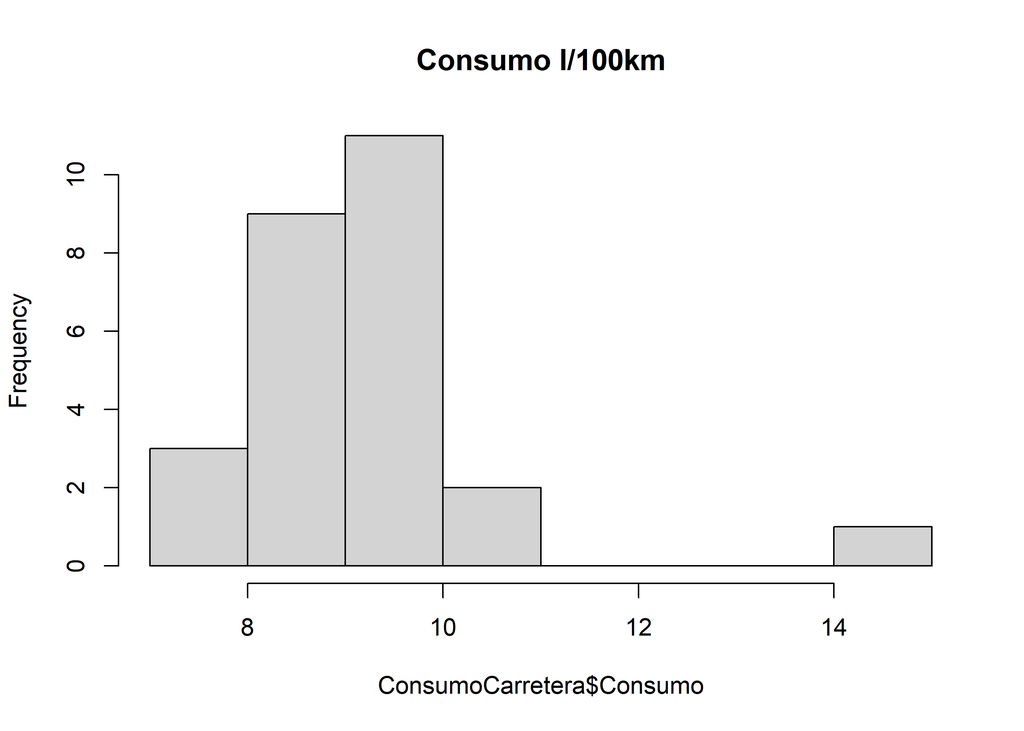

```r
hist(ConsumoCarretera$Consumo,main="Consumo l/100km")
```

El aspecto de un histograma depende de los intervalos escogidos, los mismos datos pueden producir resúmenes gráficos diferentes:

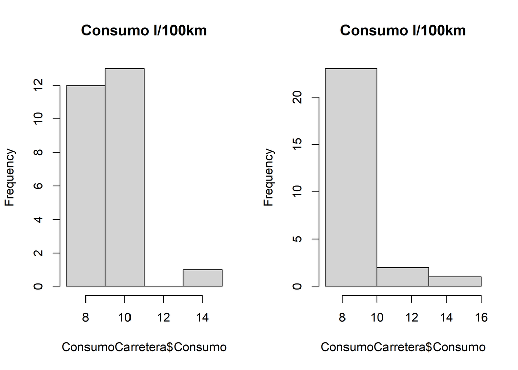

```r
par( mfrow= c(1,2) )
hist(ConsumoCarretera$Consumo,main="Consumo l/100km",
     breaks=seq(7,16,2))
hist(ConsumoCarretera$Consumo,main="Consumo l/100km",
     breaks=seq(7,16,3))
```

Incluso son los mismos intervalos la elección $(\phantom{m},\phantom{m} ]$ o $[\phantom{m},\phantom{m} )$ pueden hacer que el gráfico cambie:

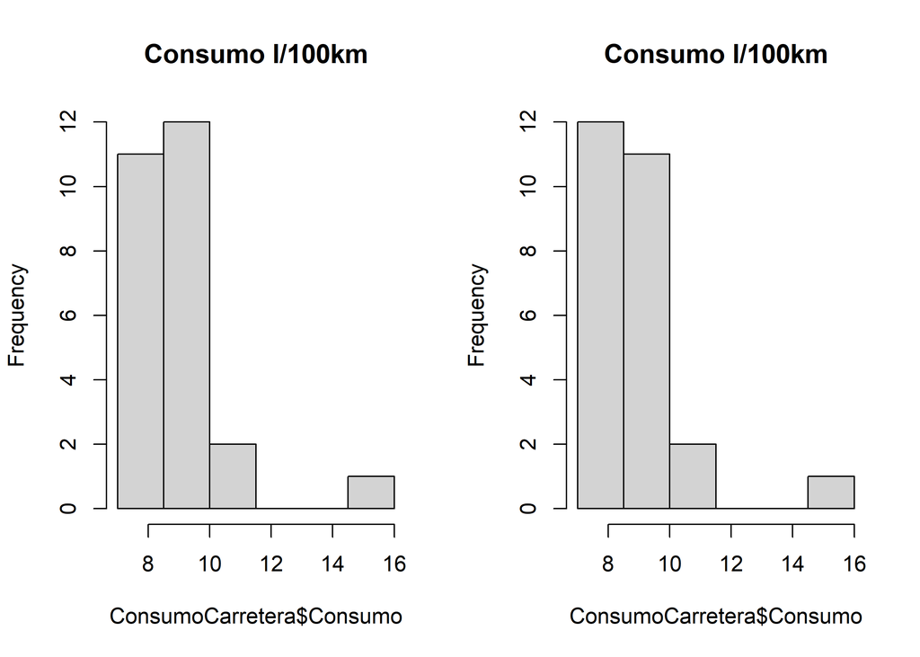

```r
par( mfrow= c(1,2) )
hist(ConsumoCarretera$Consumo,main="Consumo l/100km",
     breaks=seq(7,16,1.5),right=FALSE)
hist(ConsumoCarretera$Consumo,main="Consumo l/100km",
     breaks=seq(7,16,1.5),right=TRUE)
```

### Interpretación de un histograma

En cualquier gráfico de datos, identifica el aspecto general y las desviaciones sorprendentes del mismo.

Puedes describir el aspecto general de un histograma mediante su **forma**, su **centro** y su **dispersión**.

Un caso importante de desviación es una **observación atípica**, es decir, una observación individual que queda fuera del aspecto general.

### Distribuciones simétricas y asimétricas

Una distribución es **simétrica** si los lados derecho e izquierdo del histograma son aproximadamente imágenes especulares el uno del otro.

Una distribución es **asimétrica hacia la derecha** si el lado derecho del histograma (que contiene la mitad de las observaciones mayores) se extienden de mucho más lejos que el lado izquierdo. Una distribución es **asimétrica hacia la izquierda** si el lado izquierdo del histograma se extiende mucho más allá que el lado derecho.

> Autoevaluación I.1.4: En la Hoja 2 del conjunto de datos [Consumo Carretera](https://docs.google.com/spreadsheets/d/1uSXMzS0Rr2xNIzQTmb1n4LRZkEo54qCQoEFpc52XUbY/edit?usp=sharing) tienes datos de consumo de 19 modelos todoterreno. Construye un histograma de la variable Consumo. Repasa el [Ejemplo 1.2](https://elibro.net/es/ereader/bibliotecauclm/60046?page=52) para recordar cómo se construye un histograma. Observa la simetría o la asimetría ¿hay observaciones atípicas?
> - OJO: El histograma no es único, los cambios en el criterio de los intervalos (…] a […) pueden afectar al aspecto del gráfico.
> - OJO: Cuando los intervalos no son iguales es necesario calcular las áreas de los rectángulos, los cambios en alturas ya no son propocionales a los cambios en áreas, `frec=TRUE`, fuerza a trabajar con recuentos y es erróneo.

### Variables cuantitativas: Diagrama de tallo

Para hacer un diagrama de tallos:

- Separa cada observación en un tallo que contenga todos los dígitos menos el del final (el situado más a la derecha) y en una hoja,con el dígito del final. Los tallos pueden tener tantos dígitos como se quiera, pero cada hoja contiene un solo dígito.
- Sitúa los tallos de forma vertical en orden creciente de arriba abajo. Traza una línea vertical a la derecha de los tallos.
- Sitúa cada hoja a la derecha de su tallo, en orden creciente desde cada tallo.

```r
stem(ConsumoCarretera$Consumo)
```

```
  The decimal point is at the |

   7 | 299
   8 | 222244445
   9 | 11111555599
  10 | 33
  11 |
  12 |
  13 |
  14 | 8
```

```r
sort(ConsumoCarretera$Consumo)
```

```
 [1]  7.2  7.9  7.9  8.2  8.2  8.2  8.2  8.4  8.4  8.4  8.4  8.5  9.1  9.1  9.1
[16]  9.1  9.1  9.5  9.5  9.5  9.5  9.9  9.9 10.3 10.3 14.8
```

Puedes tener más flexibilidad **redondeando** los datos de manera que el dígito final, después del redondeo, sea adecuado como hoja. Haz esto cuando los datos tengan demasiados dígitos.

También puedes **dividir los tallos** para doblar su número cuando todas las hojas se sitúan sólo en unos pocos tallos. Cada tallo aparece, entonces, dos veces. Las hojas que van de 0 a 4 se sitúan en el tallo superior y las que van de 5 a 9 en el inferior.

> Autoevaluación I.1.5: Construye un diagrama de tallos para los datos de consumo de los todoterreno [Consumo Carretera](https://docs.google.com/spreadsheets/d/1uSXMzS0Rr2xNIzQTmb1n4LRZkEo54qCQoEFpc52XUbY/edit?usp=sharing) (Hoja 2). Repasa el [Ejemplo 1.5](https://elibro.net/es/ereader/bibliotecauclm/60046?page=61).

[Ejemplo de Datos Cuantitativos](https://docs.google.com/spreadsheets/d/1p3XnmoefMkcDdV2JcGj7C3E4xUyr_keF7ClLyoWWHFw/edit?usp=sharing)

> Intenta construir el diagrama de tallo y hojas a partir de los 10 datos e intenta recuperar los datos originales a partir del diagrama de tallo y hojas.

### Graficos temporales

Un **gráfico temporal** de una variable representa cada observación en relación con el momento en que se midió. Sitúa siempre el tiempo en el eje de las abscisas. La unión de los puntos contiguos mediante segmentos facilita la visualización de los cambios a lo largo del tiempo.

Cuando examines un gráfico temporal, fíjate una vez más en su aspecto general y en las desviaciones importantes de dicho aspecto. Un aspecto general que aparece con frecuencia es una **tendencia**; se trata de una variación, a largo plazo, creciente o decreciente.

**Ejemplo:** Intereses medios anuales pagados por fondos de inversión, [Fondos de Inversión](https://docs.google.com/spreadsheets/d/1tIibXEhJMyOTwAIY_h7Vki1oQCho8k18cNAot0fE-ZM/edit?usp=sharing) (1.10, [p. 22](https://elibro.net/es/ereader/bibliotecauclm/60046?page=64))

```r
setwd("C://Users//lrodr//Documents//OneDrive - Universidad de Castilla-La Mancha//R")
FondosInversion<-read.table("Fondos de Inversion - Hoja 1.csv", header=TRUE, sep=",")
FondosInversion
```

```
    Ano Intereses
1  1973      7.60
2  1974     10.79
3  1975      6.39
4  1976      5.11
5  1977      4.92
6  1978      7.25
7  1979     10.92
8  1980     12.88
9  1981     17.16
10 1982     12.55
11 1983      8.69
12 1984     10.21
13 1985      7.77
14 1986      6.30
15 1987      6.17
16 1988      7.09
17 1989      8.85
18 1990      7.81
19 1991      5.70
20 1992      3.31
21 1993      2.62
22 1994      3.65
23 1995      5.37
24 1996      4.80
```

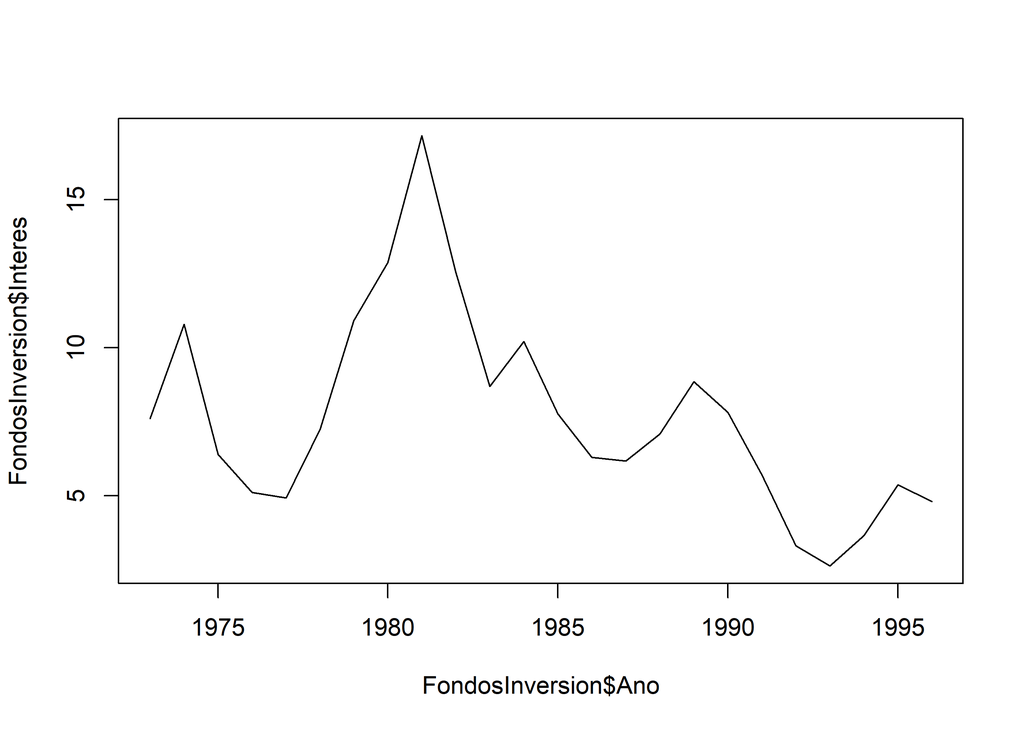

```r
plot(FondosInversion$Ano,FondosInversion$Interes, type='l')
```

> Autoevaluación I.1.7: Lee detenidamente el [Resumen 1.2](https://elibro.net/es/ereader/bibliotecauclm/60046?page=65), hace un repaso de todos los conceptos vistos hasta ahora. Los Ejercicios de la [Sección 1.2](https://elibro.net/es/ereader/bibliotecauclm/60046?page=66) están ahora a tu alcance, intenta hacerlos, ante cualquier duda: PREGUNTA.